# Our practice project

Author

LIMPO SHAWA

This Homework Project works with dataframes in the package `nycflights13` about flights, specifically a sample of domestic flights that departed from the three major New York City airports in 2013.

# 1 Data overview

## 1.1 Package loading

## 1.2 Package overview

- The data package `nycflights13` package contains five tabular data frames. In total there is information about:
  - 16 **airlines**
  - 1458 **airports**
  - 3322 **planes**
  - 336776 **flights**

The core dataframe `flights` has the following variables:

`year`, `month`, `day`: **Date** of departure.  
`dep_time`, `arr_time`: Actual **departure** and **arrival** times (format HHMM or HMM), local time zone.  
`sched_dep_time`, `sched_arr_time`: **Scheduled departure** and **arrival** times (format HHMM or HMM), local time zone.  
`dep_delay`, `arr_delay`: **Departure** and **arrival delays**, in minutes. Negative times represent early departures/arrivals.  
`carrier`: Two letter **carrier** abbreviation. See `airlines`-dataframe to get the full name.

# 2 Basic data visualization

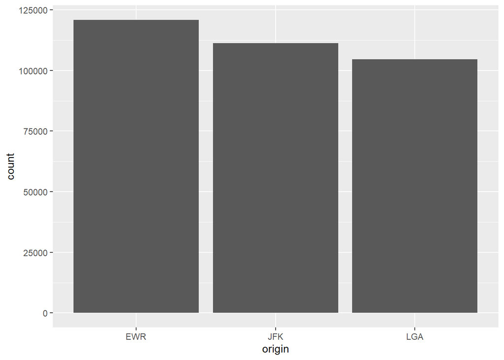

```r
ggplot(data = flights, mapping = aes(x = origin)) +
  geom_bar()
```

In the `flights` dataframe, the `EWR` airport has **120835** rows, the `JFK` has **111279** rows, and the LGA airport has **104662** rows, resulting in a total of **336776** flights.

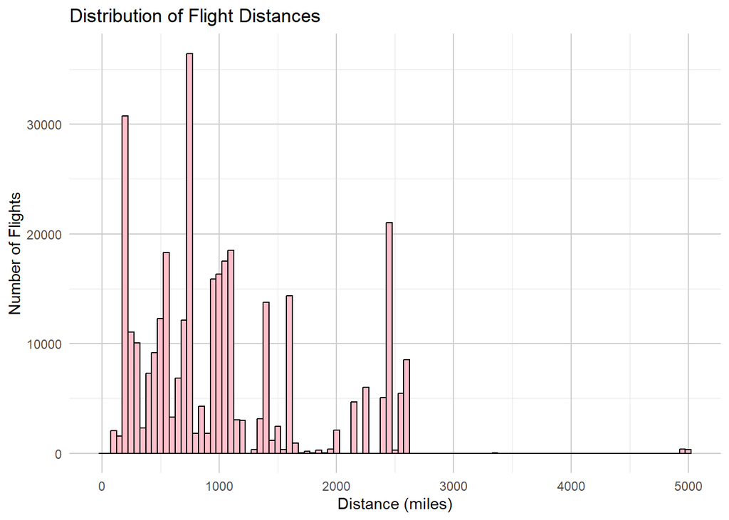

```r
ggplot(data = flights, mapping = aes(x = distance)) +
  geom_histogram(binwidth = 50, fill = "pink", color = "black") +
  labs(
    title = "Distribution of Flight Distances",
    x = "Distance (miles)",
    y = "Number of Flights"
  ) +
  theme_minimal() +
  theme(
    panel.grid.major = element_line(color = "gray80"),
    panel.grid.minor = element_line(color = "gray90")
  )
```

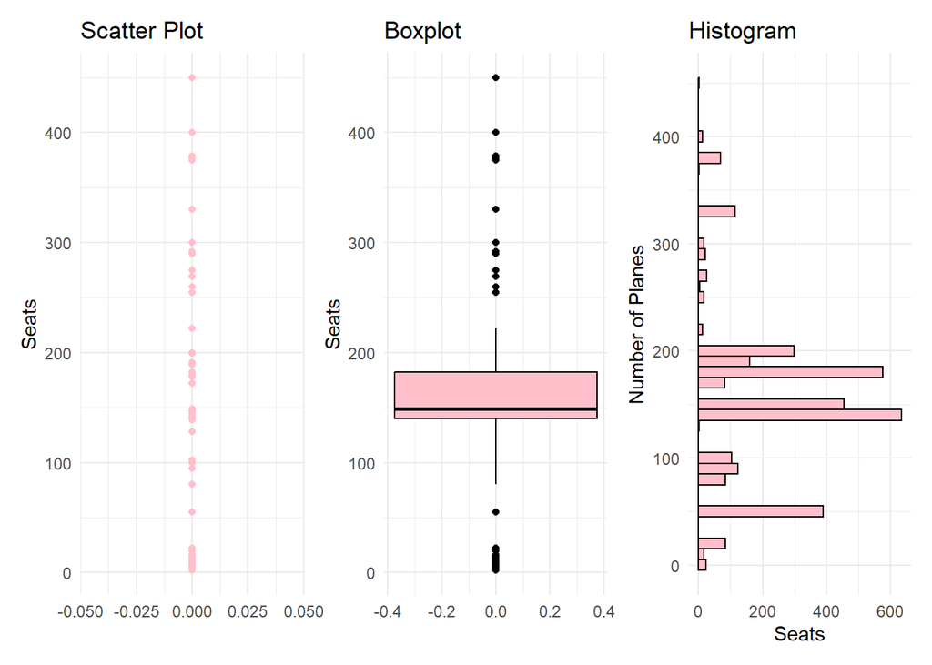

```r
# Scatter plot of seats
g1 <- ggplot(data = planes, mapping = aes(y = seats, x = 0)) +
  geom_point(color = "pink") +
  labs(title = "Scatter Plot", x = "", y = "Seats") +
  theme_minimal()

# Boxplot of seats
g2 <- ggplot(data = planes, mapping = aes(y = seats)) +
  geom_boxplot(fill = "pink", color = "black") +
  labs(title = "Boxplot", y = "Seats", x = "") +
  theme_minimal()

# Histogram of seats
g3 <- ggplot(data = planes, mapping = aes(y = seats)) +
  geom_histogram(binwidth = 10, fill = "pink", color = "black") +
  labs(title = "Histogram", y = "Number of Planes", x = "Seats") +
  theme_minimal()

# Combine the three plots
g1 + g2 + g3
```

The scatter plot (g1) shows each individual observation of seats in planes.  
The boxplot (g2) summarizes the distribution with median, quartiles, and outliers.  
The histogram (g3) shows the overall frequency distribution of seats. Each visualization has its advantages depending on what we want to see.

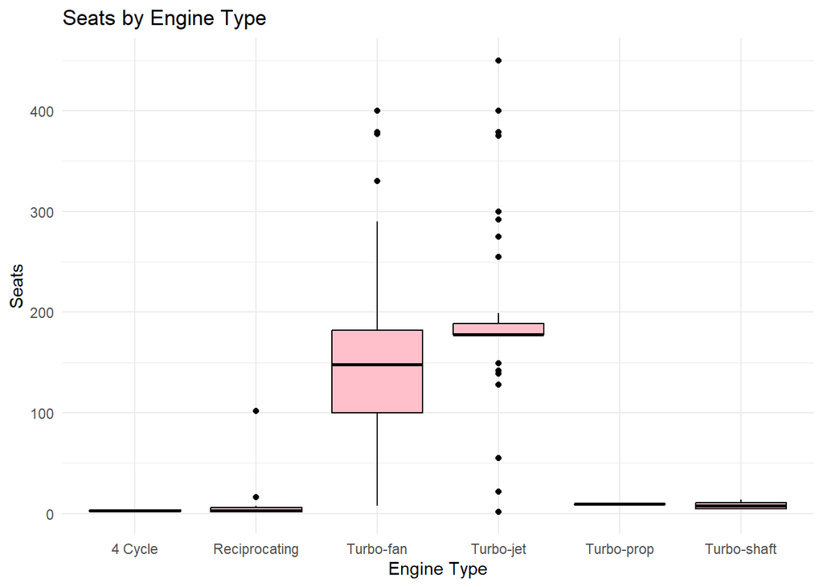

```r
ggplot(data = planes, mapping = aes(x = engine, y = seats)) +
  geom_boxplot(fill = "pink", color = "black") +
  labs(
    title = "Seats by Engine Type",
    x = "Engine Type",
    y = "Seats"
  ) +
  theme_minimal()
```

The boxplot shows how the number of seats varies by engine type.  
We can see which engine types typically have more or fewer seats and how spread out the seating capacities are.

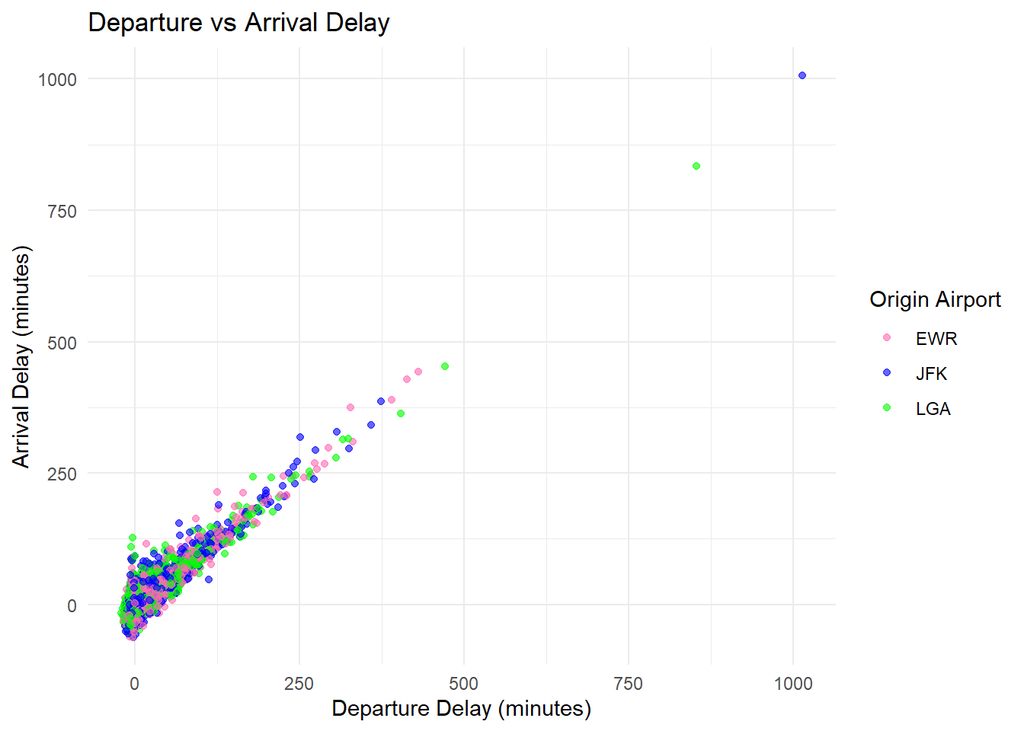

```r
library(dplyr)

# Take a random sample of 5,000 flights
sample_flights <- sample_n(flights, 5000)

# Scatter plot of departure vs arrival delays with different colors for airports
ggplot(data = sample_flights, mapping = aes(x = dep_delay, y = arr_delay, color = origin)) +
  geom_point(alpha = 0.6) +
  scale_color_manual(values = c("EWR" = "hotpink", "JFK" = "blue", "LGA" = "green")) +
  labs(
    title = "Departure vs Arrival Delay",
    x = "Departure Delay (minutes)",
    y = "Arrival Delay (minutes)",
    color = "Origin Airport"
  ) +
  theme_minimal()
```

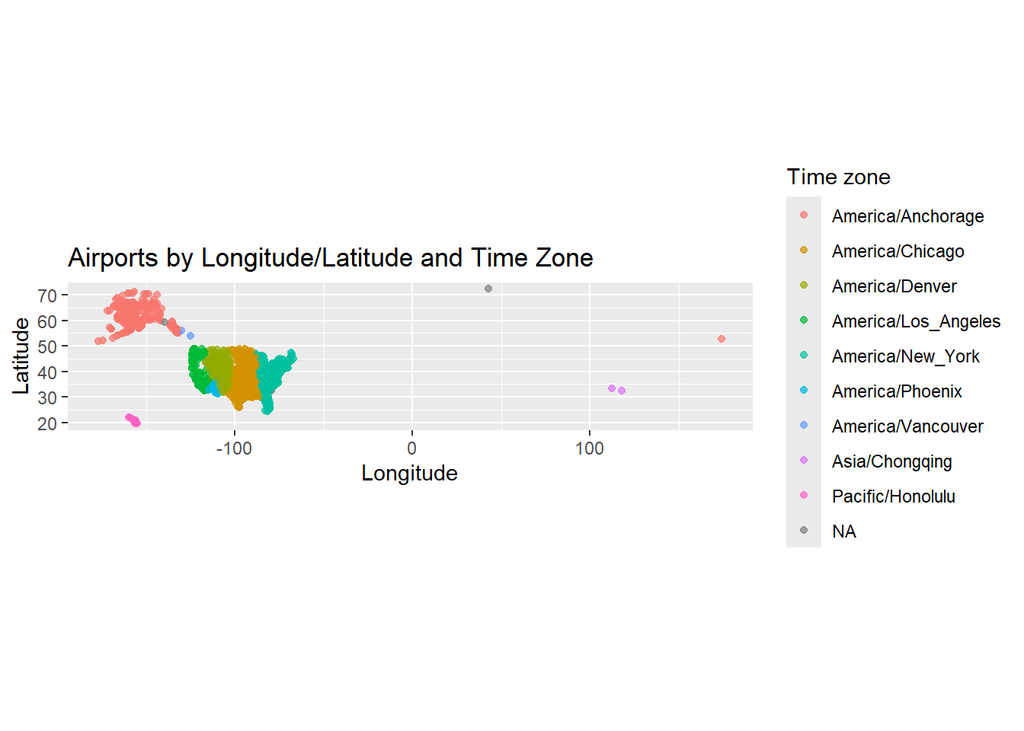

```r
ggplot(data = airports, mapping = aes(x = lon, y = lat, color =
tzone)) +
geom_point(alpha = 0.7) +
coord_quickmap () +
labs (
title = "Airports by Longitude/Latitude and Time Zone",
x = "Longitude",
y = "Latitude",
color = "Time zone"
)
```

# 3 Data Wrangling

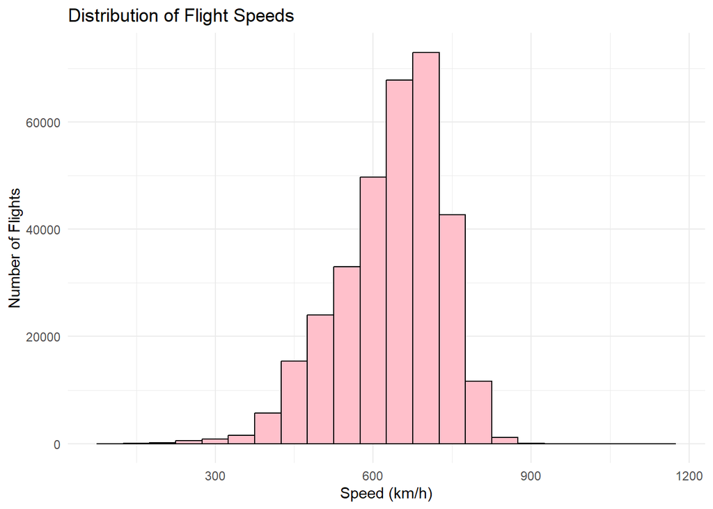

```r
flights |>
  filter(!is.na(air_time) & air_time > 0) |>  # Remove flights with missing or zero airtime
  mutate(speed = distance / (air_time / 60) * 1.60934) |>  # Convert miles/min to km/h
  ggplot(aes(x = speed)) +
  geom_histogram(binwidth = 50, fill = "pink", color = "black") +
  labs(
    title = "Distribution of Flight Speeds",
    x = "Speed (km/h)",
    y = "Number of Flights"
  ) +
  theme_minimal()
```

```r
library(knitr)

flights_filtered <- flights |>
  filter(arr_delay >= 120)

flights_filtered |>
  select(year, month, day, dep_time, arr_time, carrier, dest, arr_delay) |>
  head(10) |>
  kable(caption = "Flights with arrival delay of 2 or more hours")
```

Flights with arrival delay of 2 or more hours

| year | month | day | dep_time | arr_time | carrier | dest | arr_delay |
| --- | --- | --- | --- | --- | --- | --- | --- |
| 2013 | 1 | 1 | 811 | 1047 | MQ | CLT | 137 |
| 2013 | 1 | 1 | 848 | 1001 | MQ | BWI | 851 |
| 2013 | 1 | 1 | 957 | 1056 | UA | BOS | 123 |
| 2013 | 1 | 1 | 1114 | 1447 | UA | IAH | 145 |
| 2013 | 1 | 1 | 1505 | 1638 | EV | RIC | 127 |
| 2013 | 1 | 1 | 1525 | 1831 | B6 | MCO | 125 |
| 2013 | 1 | 1 | 1549 | 1912 | EV | MCI | 136 |
| 2013 | 1 | 1 | 1558 | 1718 | EV | IAD | 123 |
| 2013 | 1 | 1 | 1732 | 2028 | EV | DAY | 123 |
| 2013 | 1 | 1 | 1803 | 2008 | MQ | BNA | 138 |

```r
library(knitr)
flights |>
  summarize(`Average Departure Delay (minutes)` = round(mean(dep_delay, na.rm = TRUE), 0),
            .by = origin) |>
  kable(caption = "Average Departure Delay per NYC Airport")
```

Average Departure Delay per NYC Airport

| origin | Average Departure Delay (minutes) |
| --- | --- |
| EWR | 15 |
| LGA | 10 |
| JFK | 12 |

# 4 Data Audit

```r
library(dplyr)
library(knitr)
library(ggplot2)

# Filter and arrange suspect airports
suspects <- airports |>
  filter(lon > 0) |>
  select(faa, name, lat, lon, tzone) |>
  arrange(lon)

# Display a neat table
kable(suspects, caption = "Airports with positive longitude (audit targets)")
```

Airports with positive longitude (audit targets)

| faa | name | lat | lon | tzone |
| --- | --- | --- | --- | --- |
| EEN | Dillant Hopkins Airport | 72.27083 | 42.89833 | NA |
| DVT | Deer Valley Municipal Airport | 33.41170 | 112.45700 | Asia/Chongqing |
| MYF | Montgomery Field | 32.47590 | 117.75900 | Asia/Chongqing |
| SYA | Eareckson As | 52.71227 | 174.11362 | America/Anchorage |

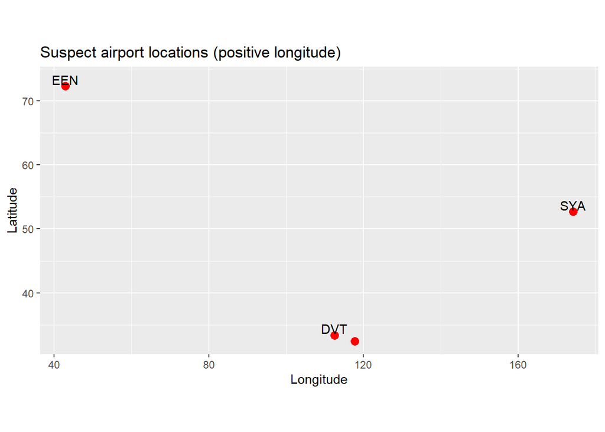

```r
# Plot suspect airports
ggplot(suspects, aes(lon, lat, label = faa)) +
  geom_point(size = 3, color = "red") +
  geom_text(nudge_y = 1, check_overlap = TRUE) +
  coord_quickmap() +
  labs(
    title = "Suspect airport locations (positive longitude)",
    x = "Longitude",
    y = "Latitude"
  )
```

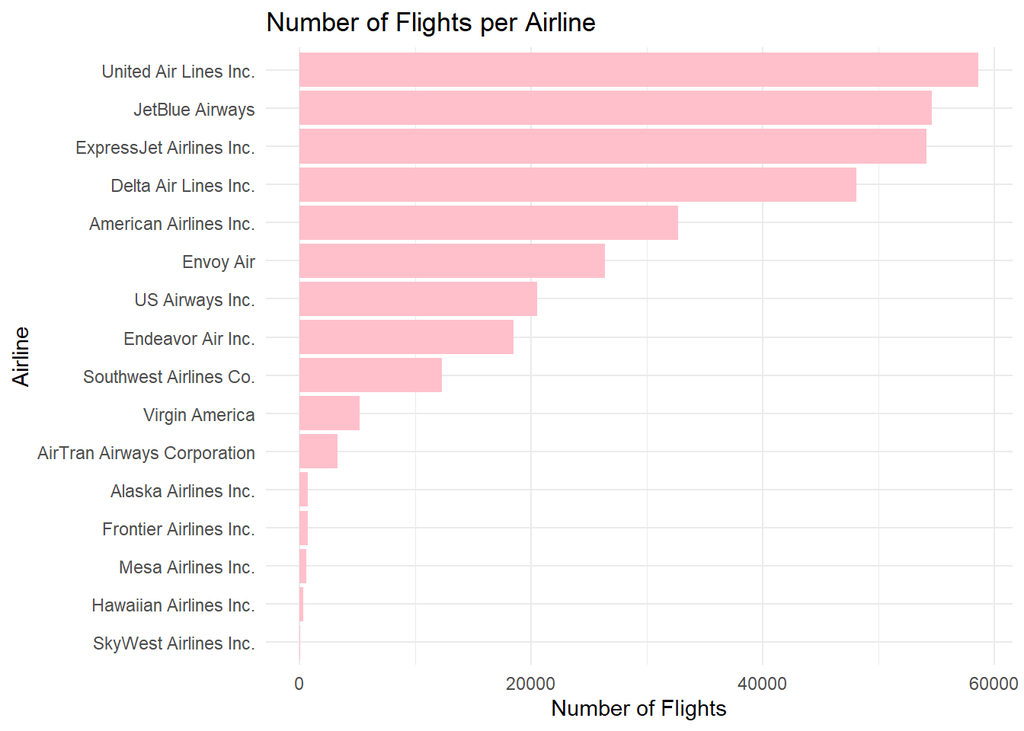

```r
library(dplyr)
library(ggplot2)
library(forcats)


flights_count <- flights |>
  count(carrier) |>
  left_join(airlines, by = "carrier") |>
  arrange(n)

# Plot horizontal bar chart
ggplot(flights_count, aes(x = n, y = fct_reorder(name, n))) +
  geom_col(fill = "pink") +
  labs(
    title = "Number of Flights per Airline",
    x = "Number of Flights",
    y = "Airline"
  ) +
  theme_minimal()
```

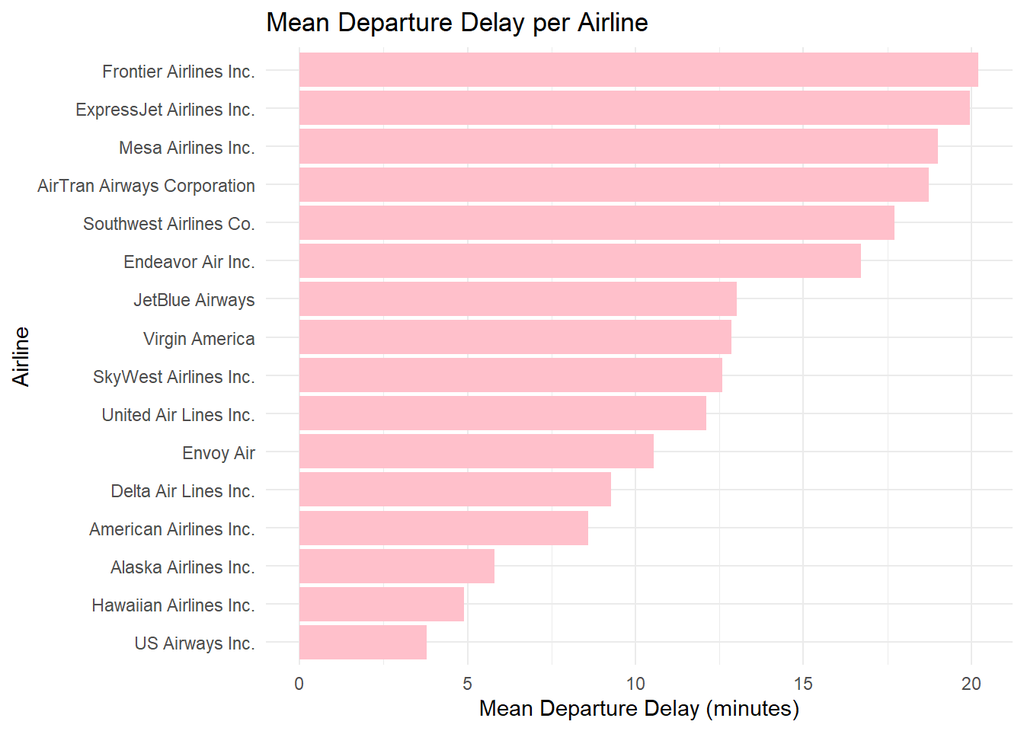

```r
library(dplyr)
library(ggplot2)
library(forcats)

# Average departure delay per airline
delay_avg <- flights |>
  group_by(carrier) |>
  summarize(mean_dep_delay = mean(dep_delay, na.rm = TRUE)) |>
  left_join(airlines, by = "carrier")

# Plot horizontal bar chart
ggplot(delay_avg, aes(x = mean_dep_delay, y = fct_reorder(name, mean_dep_delay))) +
  geom_col(fill = "pink") +
  labs(
    title = "Mean Departure Delay per Airline",
    x = "Mean Departure Delay (minutes)",
    y = "Airline"
  ) +
  theme_minimal()
```

[figure not shown]

```r
library(dplyr)
library(tidyr)
library(ggplot2)
library(forcats)

# Calculate mean departure and arrival delay per airline
delay_side <- flights |>
  group_by(carrier) |>
  summarize(
    mean_dep_delay = mean(dep_delay, na.rm = TRUE),
    mean_arr_delay = mean(arr_delay, na.rm = TRUE)
  ) |>
  left_join(airlines, by = "carrier") |>
  pivot_longer(
    cols = c(mean_dep_delay, mean_arr_delay),
    names_to = "delay_type",
    values_to = "mean_delay"
  )

# Plot side-by-side bar chart
ggplot(delay_side, aes(x = mean_delay, y = fct_reorder(name, mean_delay), fill = delay_type)) +
  geom_col(position = "dodge") +
  scale_fill_manual(
    values = c("mean_dep_delay" = "pink", "mean_arr_delay" = "hotpink"),
    labels = c("Departure Delay", "Arrival Delay")
  ) +
  labs(
    title = "Mean Departure and Arrival Delay per Airline",
    x = "Mean Delay (minutes)",
    y = "Airline",
    fill = "Delay Type"
  ) +
  theme_minimal()
```

**Note:** Some delays are negative because they represent flights that departed or arrived **earlier than scheduled**.  
- Positive values → late  
- Zero → on time  
- Negative values → early

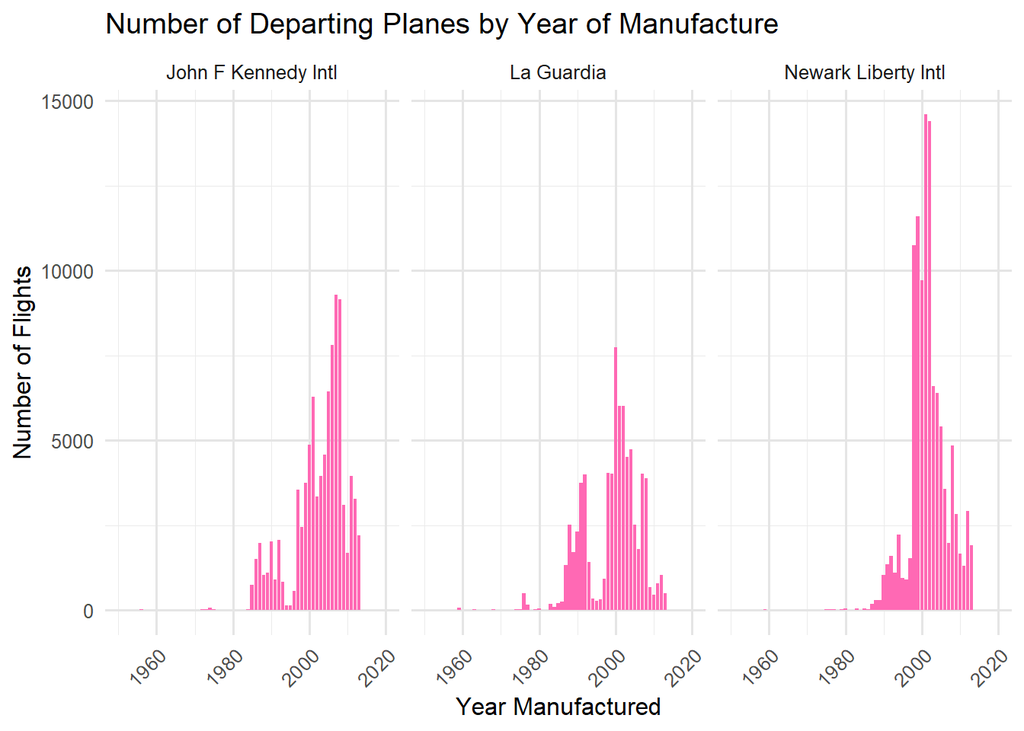

```r
library(dplyr)
library(ggplot2)

planes_data <- flights |>
  left_join(planes |> rename(manufacture_year = year), by = "tailnum") |>
  left_join(airports, by = c("origin" = "faa"))

planes_count <- planes_data |>
  filter(!is.na(manufacture_year)) |>
  group_by(name, manufacture_year) |>
  summarize(num_flights = n(), .groups = "drop")

ggplot(planes_count, aes(x = manufacture_year, y = num_flights)) +
  geom_col(fill = "hotpink") +
  facet_wrap(~name) +
  labs(
    title = "Number of Departing Planes by Year of Manufacture",
    x = "Year Manufactured",
    y = "Number of Flights"
  ) +
  scale_x_continuous(limits = c(1950, 2020)) +
  theme_minimal(base_size = 12) +
  theme(
    axis.text.x = element_text(angle = 45, hjust = 1),
    panel.grid.major = element_line(color = "gray90")
  )
```

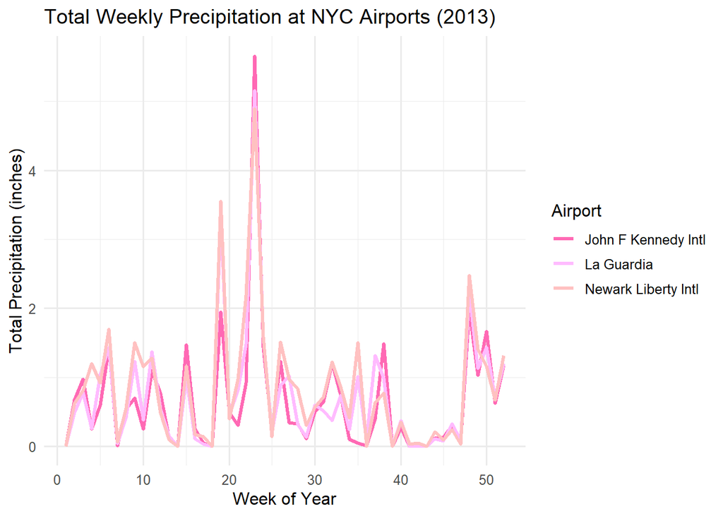

```r
library(dplyr)
library(lubridate)
library(ggplot2)

# Lookup full airport names
airports_lookup <- airports |>
  dplyr::select(faa, name) |>
  dplyr::rename(origin_name = name)

# Aggregate weekly precipitation
weekly_precip <- weather |>
  dplyr::mutate(
    date = as.Date(paste(year, month, day, sep = "-")),
    week = lubridate::week(date)
  ) |>
  dplyr::left_join(airports_lookup, by = c("origin" = "faa")) |>
  dplyr::summarize(total_precip = sum(precip, na.rm = TRUE), .by = c(origin_name, week))

ggplot(weekly_precip, aes(x = week, y = total_precip, color = origin_name)) +
  geom_line(linewidth = 1.2) +
  scale_color_manual(values = c(
    "John F Kennedy Intl" = "hotpink",
    "La Guardia" = "plum1",
    "Newark Liberty Intl" = "rosybrown1"
  )) +
  labs(
    title = "Total Weekly Precipitation at NYC Airports (2013)",
    x = "Week of Year",
    y = "Total Precipitation (inches)",
    color = "Airport"
  ) +
  theme_minimal(base_size = 12)
```

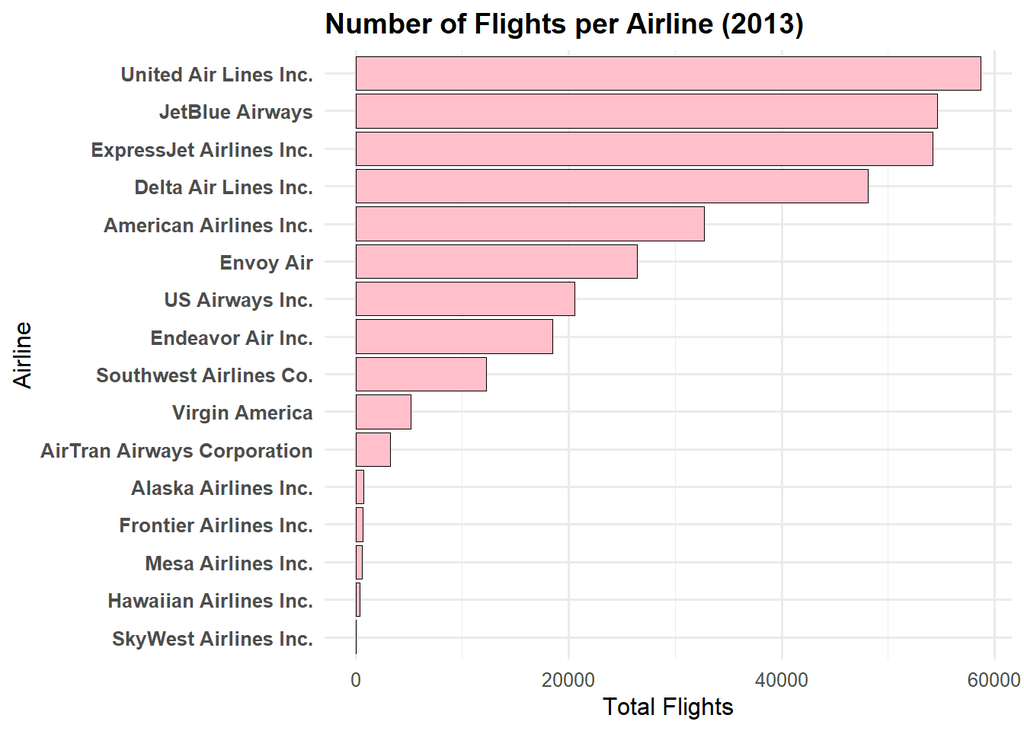

```r
library(dplyr)
library(ggplot2)

# Count flights per airline
flights_per_airline <- flights |>
  left_join(airlines, by = "carrier") |>
  group_by(name) |>
  summarize(total_flights = n(), .groups = "drop")

ggplot(flights_per_airline, aes(x = reorder(name, total_flights), y = total_flights, fill = name)) +
  geom_col(linewidth = 0.2, color = "black") +
  coord_flip() +
  scale_fill_manual(values = rep("pink", nrow(flights_per_airline))) +
  labs(
    title = "Number of Flights per Airline (2013)",
    x = "Airline",
    y = "Total Flights",
    fill = "Airline"
  ) +
  theme_minimal(base_size = 12) +
  theme(
    legend.position = "none",
    plot.title = element_text(face = "bold", size = 14),
    axis.text.y = element_text(face = "bold")
  )
```

```r
# Show top airline as inline code
top_airline <- flights_per_airline |>
  slice_max(total_flights, n = 1)

top_airline_name <- top_airline$name
top_airline_count <- top_airline$total_flights

top_airline_name
```

```
[1] "United Air Lines Inc."
```

```r
top_airline_count
```

```
[1] 58665
```

## 4.1 Your Own Data Science Question

**Question:** Which airline operated the most flights from NYC airports in 2013?

The bar chart above shows the total number of flights for each airline.  
The airline with the most flights in 2013 was **United Air Lines Inc.** with a total of **58,665** flights.

**Interpretation:**  
This shows that **United Air Lines Inc.** was the busiest airline in NYC in 2013. Choosing flights with this airline might increase options and frequency, but could also mean busier airports and potentially more delays.